# econ2200Ch08 slides

## ECON2200H

### Introduction to Statistics for Economics and Management

### 2020 Winter Term

### Week 07: Point Estimation and Confidence Intervals

#### 24 February 2020

### Reading: Chapter 8 of textbook.

## Outline

- Point estimation
- Confidence intervals
- Example: estimates of mean and of proportion

## So far, we

- studied the random variables and their distributions,
- which is used to characterize mathematical properties of **random samples** and **sampling distributions**.
- **Sampling distribution** is the probability distribution of a statistic computed from a random sample.
- For example, the sample mean $\overline{X}_n$ has approximately a normal sampling distribution.

## We now move to estimation

- The values of parameters of sampling distribution (and in population distribution) are to be estimated.

## 1. Point estimation

- A **point estimate** is a single statistic computed from a random sample, used to "guess" a population parameter.
- Population parameter: quantities that characterize the population distribution.
- Example. The expected value, $\mu$, of a population distribution is a population parameter, it can be estimated from a random sample $X_1, X_2,\cdots$. We can take the sample mean, $\overline{X}_n$, as an **estimate** of $\mu$. We write, $\widehat{\mu}=\overline{X}_n$.
- **Example**: labor earnings again.

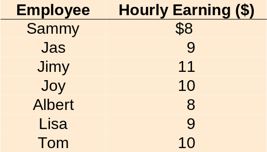

- Any of the sample mean can be an estimate of $\mu$.

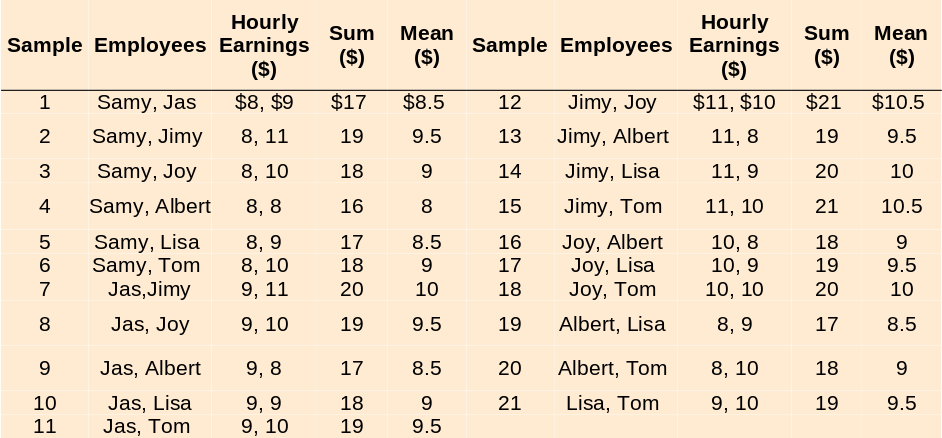

- Point estimation of different population parameters when $N$ and $n$ are sufficiently large.

| Population Parameter | Estimate of population parameter | Variance of Estimate | Estimated variance |
| --- | --- | --- | --- |
| $\mu$ | $\overline{X}_n = \frac{1}{n} \sum_{i=1}^n X_i$ | $\sigma_{\overline{X}}^2 = \frac{\sigma^2}{n}$ | $s_{\overline{X}}^2 =\frac{s^2}{n}$ |
| $\sigma^2$ | $s^2$ |  |  |
| $p$ | $\overline{p} = \frac{K}{n}$ | $\sigma_{\overline{p}}^2 = \frac{p(1-p)}{n}$ | $s_{\overline{p}}^2 =\frac{\overline{p}(1-\overline{p})}{n-1}$ |

- In the table, $s^2 = \frac{1}{n-1}[(X_1-\overline{X}_n)^2+(X_2-\overline{X}_n)^2+\cdots+(X_n-\overline{X}_n)^2]$.
- The square roots of variance of estimate (3rd column) are called **standard errors**.
- THe square roots of estimated variance (4th column) are called **estimated standard errors**.

### Finite-population correction for point estimation

- Estimates in the above slides are based on random sampling *with replacement*. Empirically it applies to when sample size $n$ is large, but still smaller than $N$, meaning $N$ should be sufficiently large too.
- In many cases, random sampling is drawn *without replacement*, or population size $N$ is not large, it is finite.
- In a finite population, the point estimation of population parameters is corrected by a factor $\frac{N-n}{N-1}$ or $\frac{N-n}{N}$, so called the **finite-population correction**.
- Point estimation of different population parameters with finite-population correction.

| Population Parameter | Estimate of population parameter | Variance of Estimate with correction | Estimated variance with correction |
| --- | --- | --- | --- |
| $\mu$ | $\overline{X}_n = \frac{1}{n} \sum_{i=1}^n X_i$ | $\sigma_{\overline{X}}^2 = \frac{\sigma^2}{n}\left(\frac{N-n}{N-1}\right)$ | $s_{\overline{X}}^2 =\frac{s^2}{n}\left(\frac{N-n}{N}\right)$ |
| $\sigma^2$ | $\frac{N-1}{N}s^2$ |  |  |
| $p$ | $\overline{p} = \frac{K}{n}$ | $\sigma_{\overline{p}}^2 = \frac{p(1-p)}{n}\left(\frac{N-n}{N-1}\right)$ | $s_{\overline{p}}^2 =\frac{\overline{p}(1-\overline{p})}{n-1}\left(\frac{N-n}{N}\right)$ |

- In the table, $s^2 = \frac{1}{n-1}[(X_1-\overline{X}_n)^2+(X_2-\overline{X}_n)^2+\cdots+(X_n-\overline{X}_n)^2]$.
- NOTE: Formulas in the 4th column slightly differ from those on page 263 of textbook (formulas 8-6, 8-7, 8-8). Consider both are correct.
- Why are these estimates?
- The estimates reported in above tables are not the only ones we can use. Importantly, the estimates reported in the tables are the "best" ones: they were proved to approach to true values of population parameters when sample size is sufficiently large.
- **Bias**: the bias of the estimate of population mean is defined as $\overline{X}_n-\mu$. Estimate is **unbiased** if $E[\overline{X}_n]-\mu=0$. This applies to any estimates of any population parameter.
- Unbiasedness is one measure of being the "best" estimates.

## 2. Confidence intervals

- Point estimates are likely different from true values of parameters. We want to know how close they are to true values. We can use the confidence intervals.
- A **$100(1-\alpha)\%$ confidence interval** of the population mean $\mu$ is a *random interval* $[a,b]$ such that the value of $\mu$ lies in $[a,b]$ with probability $1- \alpha$. The random interval is computed from a random sample.
- That is, random interval $[a,b]$ traps $\mu$ with probability $1-\alpha$.
- E.g., a $95\%$ confidence interval for $\mu$ is a random interval $[a,b]$ that contains $\mu$ with probability 0.95. Here, $\alpha = 0.05$.
- Interpretation: if we take many random samples, and form a confidence interval for each random sample, about $95\%$ of these intervals would contain $\mu$.

### 2-1. Confidence interval for $\mu$ when population standard deviation $\sigma$ is known

- Recall, by the central limit theorem, $\frac{\overline{X}_n - \mu}{\sigma_{\overline{X}}}$ has approximately a standard normal distribution. $\overline{X}_n$ is the sample mean, and is the estimate of $\mu$. $\sigma_{\overline{X}}$ is the standard deviation of the sampling mean, where $\sigma$ is the population standard deviation. Then $$P\left(-z_{\alpha}<\frac{\overline{X}_n - \mu}{\sigma_{\overline{X}}}<z_{\alpha}\right) = 1-\alpha.$$
- Also recall, $1-\alpha$ is the area under the graph of normal probability density function between $-z_{\alpha}$ and $z_{\alpha}$.
- For example, from the standard normal distribution table (Appendix B.1 of textbook), we know that $z_{\alpha}= 1.96$ if $\alpha=0.05$.

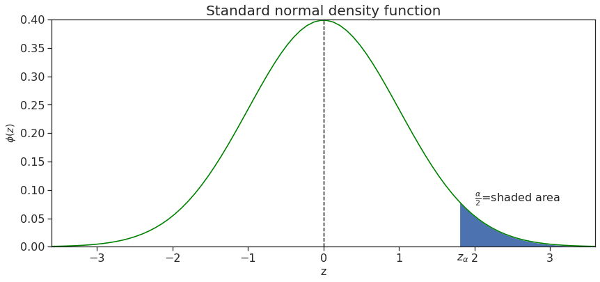

```python
%matplotlib inline
import numpy as np;
from scipy.stats import norm;
import matplotlib.pyplot as plt;
import seaborn;
seaborn.set(style='ticks');
x = np.linspace(norm.ppf(0.0000001),norm.ppf(0.9999999), 120);
pdfx = norm.pdf(x);
fig, ax = plt.subplots(nrows=1, ncols=1, figsize=(14, 6), sharey='all');
ax.plot(x,pdfx, color="green", linewidth=1.6, linestyle="-");
ax.fill_betweenx(pdfx,x,x2=1.8, where = x>1.8,interpolate=True);
plt.axvline(x=0.0, color='black', linewidth=1.4,linestyle='--');
plt.text(2.0,.08,'\n$\\frac{\\alpha}{2}$=shaded area',fontsize=16, horizontalalignment='left');
plt.text(1.76,-.025,'\n$z_{\\alpha}$',fontsize=16, horizontalalignment='left');
plt.autoscale(enable=True, axis='x', tight=True);
ax.set_title('Standard normal density function', fontsize=20);
ax.tick_params(axis='y', labelsize=16);
ax.tick_params(axis='x', labelsize=16);
ax.set_xlim([-3.6,3.6]);
ax.set_ylim([0.0,0.4]);
plt.xlabel("z", fontsize=16);
ax.set_ylabel('$\phi(z)$', fontsize=14);
#ax.set_aspect('equal')
#fig.tight_layout();
```

- Rearranging the inequalities, we obtain $$P\left(\overline{X}_n-z_{\alpha}\cdot \sigma_{\overline{X}} < \mu<\overline{X}_n + z_{\alpha}\cdot \sigma_{\overline{X}}\right) = 1-\alpha.$$
- The probability that $\mu$ lies in the interval $[\overline{X}_n-z_{\alpha} \cdot \sigma_{\overline{X}},\ \overline{X}_n+z_{\alpha}\cdot \sigma_{\overline{X}}]$ is $1-\alpha$. This interval is called a $100(1-\alpha)\%$ confidence interval for $\mu$.
- The value of $z_{\alpha}$ is obtained from the standard normal distribution table, once the value of $\alpha$ is determined.
- Example. The $95\%$ confidence interval for the population mean $\mu$ is $\overline{X}_n \pm 1.96 \sigma_{\overline{X}}$.
- How do we obtain $z_{\alpha} = 1.96$ in the $95\%$ confidence interval?

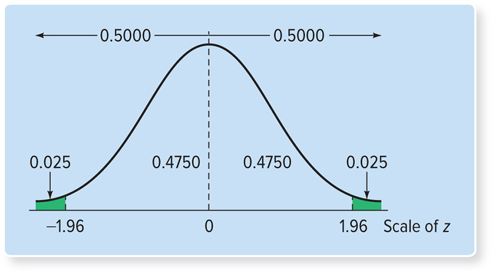

- Note, Confidence interval is random, since $\overline{X}_n$ is so.
- The confidence interval can be computed given any random sample, and only if we know $\sigma$ since $\sigma_{\overline{X}}=\frac{\sigma}{\sqrt{n}}$ or $\sigma_{\overline{X}}=\frac{\sigma}{\sqrt{n}} \sqrt{\frac{N-n}{N-1}}$.
- Recall, $\sigma^2$ is the population variance. Its true value is frequently unknown and remains to be estimated.

### 2-2. Confidence interval for $\mu$ when population standard deviation $\sigma$ is unknown

- When the value of $\sigma^2$ is **unknown**, we can no longer use the confidence interval $\overline{X}_n \pm z_{\alpha} \sigma_{\overline{X}}$ for population mean $\mu$.
- Fortunately, the quantity $\frac{\overline{X}_n - \mu}{s_{\overline{X}}}$ has the **student's $t$ distribution** or simply the **$t$ distribution**.
- The $t$ distribution is symmetric about zero. It is similar to standard normal distribution.
- The probability density function of a random variable following the $t$ distribution depends on the random sample size $n$. As $n$ goes to infinity, the $t$ distribution tends to the standard normal distribution.
- Probability density function for standard normal random variables, for random variables with $t$ dsitribution

[figure not shown]

- The $100(1-\alpha)\%$ confidence interval for population mean $\mu$ is then $\overline{X}_n \pm t_{\alpha} \cdot s_{\overline{X}}$, where $t_{\alpha}$ satisfies $$P\left(-t_{\alpha}<\frac{\overline{X}_n - \mu}{s_{\overline{X}}}<t_{\alpha}\right) = 1-\alpha.$$
- But this probability is the area under the graph of the probability density function for a random variable with the $t$ distribution.
- Example. The $95\%$ confidence interval of population mean from a random sample of size $n=5$ is $\overline{X}_n \pm 2.776 \cdot s_{\overline{X}}$.
- Refer to Section 1 of these slides for the expression for $s_{\overline{X}}$. Again, Equation [8-7] on page 263 of textbook is also considered to be correct.
- Probability density function for standard normal random variables, for random variables with $t$ dsitribution

[figure not shown]

### 2-3. Confidence intervals for population proportion $p$

- The $100(1-\alpha)\%$ confidence interval for population proportion is $\overline{p} \pm z_{\alpha} \cdot \sigma_{\overline{p}}$ when $p$ is known, and $\overline{p} \pm z_{\alpha} \cdot s_{\overline{p}}$ when $p$ is unknown.
- The construction of these intervals are similar to those for the population mean, since $\overline{p}$ has approximately a normal distribution.
- We follow the textbook, and use the standard normal distribution to construct the confidence intervals when $p$ is known and is unknown, unless explicitly asked.

## 3. Appropriate sample size $n$

- From the idea of the confidence interval, we can decide the sample size $n$.
- We define the **margin of error** as $E_m = z_{\alpha} \frac{\sigma}{\sqrt{n}}$.
- To decide the sample size $n$, we first determine the size of $E_m$, then $$n = \left(\frac{z_{\alpha} \sigma}{E_m}\right)^2.$$
- Here, $z_{\alpha}$ is again the standard normal value corresponding to the desired level of confidence $100(1-\alpha)\%$.
- Example. Suppose one wants to survey a random sample of employees in the retail industry. The desired margin of error is determined to be at most $\$300$, further suppose that one knows the population standard deviation to be $\$3000$. What is the necessary size of the random sample?
- This depends on the level of confidence, further again suppose that one wants the confidence level computed from the random sample to be $95\%$.
- Then, $n = \left(\frac{1.96 \cdot 3000}{300}\right)^2 = 384$.